# FigureYa48 Adonis

# Academic Citation

If you use this code in your work or research, we kindly request that you cite our publication:

Xiaofan Lu, et al. (2025). FigureYa: A Standardized Visualization Framework for Enhancing Biomedical Data Interpretation and Research Efficiency. iMetaMed. https://doi.org/10.1002/imm3.70005

## 需求描述

## Requirement description

进行置换多元方差分析（PERMANOVA，Adonis），画出图b

Perform permutational multivariate analysis of variance (PERMANOVA, Adonis) and draw Figure b.

[figure not shown]

图 1：取样区域和肠道微生物群区域差异概览。 b，条形图说明了与肠道微生物变化显著相关的前 30 个宿主因素。这些变化来自样本间加权的 UniFrac 距离。条形图根据元数据类别着色。规模效应和统计显著性由 PERMANOVA (Adonis) 计算。FDR控制在5%。DBP：舒张压；TCHO：总胆固醇；FBG：空腹血糖。

出自https://www.nature.com/articles/s41591-018-0164-x

Fig. 1: Overview of sampling regions and of regional variation in gut microbiota. b, Bar plot illustrating the top 30 host factors found to be significantly associated with gut microbial variations. The variations were derived from between-sample weighted UniFrac distances. The bars are colored according to metadata categories. Size effect and statistical significance were calculated by PERMANOVA (Adonis). FDR was controlled at 5%. DBP, diastolic blood pressure; TCHO, total cholesterol; FBG, fasting blood glucose.

fromhttps://www.nature.com/articles/s41591-018-0164-x

## 应用场景

## Application scenario

分析不同分组或环境因子对样品差异的解释度，例如例文中宿主的临床表型对肠道微生物的影响。

Analyze the explanatory power of different groups or environmental factors on sample differences, such as the impact of the host’s clinical phenotype on gut microbiota in the example text.

## 输入数据

## Input data

三个输入文件：

Three input files:

```r
source("install_dependencies.R")
```

```
## Starting R package installation...
## ===========================================
##
## Installing CRAN packages...
## Package already installed: ggplot2
## Package already installed: vegan
##
## ===========================================
## Package installation completed!
## You can now run your R scripts in this directory.
```

```r
#肠道微生物数据，每行为一种肠道微生物，每一列为一个样本
#gut microbiota data, each row represents a type of gut microbe, and each column represents a sample
mydata <- read.table("easy_input_meta.txt",head=T,sep = "\t",row.names = 1)
mydata <- t(mydata) #转置
mydata[1:3,1:4]
```

```
##         Achimill Agrostol Airaprae Alopgeni
## sample1        1        0        0        0
## sample2        3        0        0        2
## sample3        0        4        0        7
```

```r
#理化因子表格，每行为一个样本，每一列为一个因子，例如年龄、疾病、吸烟等
#physicochemical factor table, one sample per row, one factor per column, e.g., age, disease, smoking, etc.
myfactor <- read.table("easy_input_factors.txt",header = T,sep = "\t", row.names = 1)
head(myfactor)
```

```
##          A1 Moisture Management      Use Manure
## sample1 2.8        1         SF Haypastu      4
## sample2 3.5        1         BF Haypastu      2
## sample3 4.3        2         SF Haypastu      4
## sample4 4.2        2         SF Haypastu      4
## sample5 6.3        1         HF Hayfield      2
## sample6 4.3        1         HF Haypastu      2
```

```r
#非必需，理化因子的分组信息，例如某几个因子都属于生活方式
#non-essential, grouping information of physicochemical factors, for example, certain factors all belong to lifestyle
gp <- read.table("easy_input_factor.group.txt",head=F,sep = "\t")
colnames(gp) <- c("factor","group")
head(gp)
```

```
##       factor  group
## 1         A1    Num
## 2   Moisture    Num
## 3 Management String
## 4        Use String
## 5     Manure    Num
```

## 开始计算

## Start calculating

```r
# 进行adonis分析
# perform adonis analysis
library(vegan)
result <- adonis2(mydata ~ .,
                  data = myfactor,
                  by = "terms",        # 按项计算（与原始adonis相同）
                  permutations = 999,  # 置换次数，默认999
                  method = "bray",     # 距离方法，默认是"bray"（Bray-Curtis）
                  strata = NULL,       # 分层变量，如果需要分层置换检验
                  parallel = getOption("mc.cores") # 并行计算核心数
                  )

mytable <- as.data.frame(result)
mytable <- mytable[1:ncol(myfactor),]

# 是否进行p值校正并根据校正后p值挑选
# whether or not to perform p-value correction and select based on the corrected p-value
fdr <- T

if(fdr == T){
  # p.adjust
  mytable$fdr <- p.adjust(mytable$`Pr(>F)`, method = "fdr")
  # 根据fdr挑选理化因子
  # select physicochemical factors based on fdr
  choose <- mytable[mytable$fdr < 0.05,]
}else{
  choose <- mytable[mytable$`Pr(>F)` < 0.05,]
}

# 把计算结果保存到文件，可以像例文那样，作为文章的补充材料
# save the calculations to a file that can be used as additional material for the article, as in the example essay
write.csv(choose, "output_Adonis.csv", quote = F)
```

## 开始画图

## Start drawing

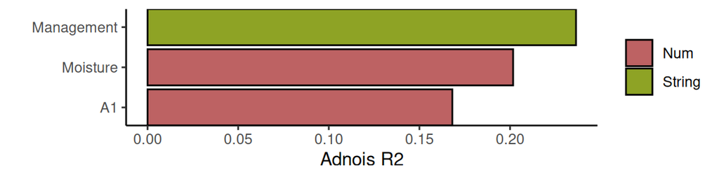

```r
library(ggplot2)
#根据R2排序
#sort by R2
choose <- choose[order(choose$R2),]
choose$factor <- factor(row.names(choose),levels=row.names(choose))

#定义足够多的颜色，对应理化因子分组的数量
#define a sufficient number of colors corresponding to the number of physicochemical factor groupings
mycol <- c("#BD6263","#8EA325","#A9D179","#84CAC0","#F5AE6B","#BCB8D3","#4387B5")

#理化因子有无分组
#physical and chemical factors with or without grouping
group <- T #此处有分组信息 grouping information is available here

if (group == T) {
  choose <- merge(choose,gp,by="factor")
  ggplot(choose,aes(x=factor, y=R2, fill = group)) + #按分组填充颜色 fill color by group
    geom_bar(stat = "identity",color = "black") + #bar有黑色边框 bar has a black border
    scale_x_discrete(expand = c(0,0)) + #上下不留空 do not leave it blank up and down
    scale_fill_manual(values = mycol) + #使用自定义的配色 use a custom color scheme

    labs(x="",y="Adnois R2") +
    coord_flip() + #坐标轴互换 coordinate-axis interchange

    theme_bw() + #去除背景色 remove background color
    theme(panel.grid =element_blank()) + #去除网格线 remove gridlines
    theme(panel.border = element_blank()) + #去除外层边框 remove outer border
    theme(axis.line = element_line(colour = "black")) +#沿坐标轴显示直线 display lines along the axes

    guides(fill = guide_legend(title = NULL))

} else {
  #不提供分组信息的情况
  #circumstances in which grouping information is not provided
  ggplot(choose,aes(x=factor,y=R2),fill = "black") +
    geom_bar(stat = "identity",color = "black") +
    scale_x_discrete(expand = c(0,0)) +

    labs(x="", y="Adnois R2") +
    coord_flip() +
    theme_bw() +
    theme(panel.grid =element_blank()) +
    theme(panel.border = element_blank()) +
    theme(axis.line = element_line(colour = "black")) +

    guides(fill = guide_legend(title = NULL))
}
```

```r
#保存到PDF文件
#save to PDF file
ggsave("adonis_barplot.pdf")
```